# Interpretability for Tree Ensembles

Biostat 212A

Author

Dr. Jin Zhou @ UCLA

Published

March 7, 2026

Credit: This note builds on tree/ensemble material from [*An Introduction to Statistical Learning: with Applications in R*](https://www.statlearning.com/) (ISL2) and [*Elements of Statistical Learning*](https://hastie.su.domains/ElemStatLearn/) (ESL2), and introduces modern interpretability tools including **permutation importance** and **SHAP**.

Display system information for reproducibility.

**R**

**Python**

```python
import IPython
print(IPython.sys_info())
```

```
{'commit_hash': '5ed988a91',
 'commit_source': 'installation',
 'default_encoding': 'utf-8',
 'ipython_path': '/Users/jinjinzhou/.virtualenvs/r-tensorflow/lib/python3.10/site-packages/IPython',
 'ipython_version': '8.33.0',
 'os_name': 'posix',
 'platform': 'macOS-15.7.4-arm64-arm-64bit',
 'sys_executable': '/Users/jinjinzhou/.virtualenvs/r-tensorflow/bin/python',
 'sys_platform': 'darwin',
 'sys_version': '3.10.16 (main, Mar  3 2025, 20:01:33) [Clang 16.0.0 '
                '(clang-1600.0.26.6)]'}
```

# 1 The problem: ensembles are black boxes

A single decision tree is readable — you can trace the splitting rules and explain any prediction in a few steps.

But the models that *win* in practice are ensembles (random forests, boosting), which combine hundreds of trees. A single tree says: “If `CRuns > 300` and `CRBI > 200`, predict high salary.” A 500-tree random forest just says: “The predicted salary is $842K” — *but why?*

We need tools to look inside. Two questions drive everything that follows:

1. **Which variables matter?** (variable importance)
2. **How does each variable affect a specific prediction?** (SHAP)

**NoteImportance $\neq$ causality**

A variable can be “important” because it correlates with the outcome, correlates with a true cause, or even due to data leakage. Importance answers: “Does the model rely on this variable?” — not “Does this variable cause the outcome?”

# 2 Variable importance: two flavors

## 2.1 Split / impurity importance (built into trees)

Every time a tree splits on feature $j$, the impurity (RSS, Gini, entropy) decreases by some amount $\Delta I(t)$. Sum those decreases over all splits on feature $j$, across all trees:

$$VI_j = \sum_{t:\, \text{split variable}=j} \Delta I(t).$$

This is computed for free during training and available in every tree library. But it can be **biased** toward high-cardinality features and tends to **split credit** unpredictably among correlated predictors.

## 2.2 Permutation importance (model-agnostic)

A cleaner idea: measure how much the model’s performance *drops* when you destroy a feature’s information.

1. Score the model on held-out data → baseline metric $m_0$.
2. Randomly shuffle feature $j$ (break its link with $y$).
3. Re-score → $m_j$.
4. Importance $= m_0 - m_j$.

This works for any model and any metric. The main caveat: with correlated features, shuffling $X_j$ may not hurt much because $X_k$ substitutes for it.

**WarningThe correlated-features trap**

If $X_1$ and $X_2$ carry nearly the same information, **split importance** shares credit roughly 50/50 (neither looks dominant), while **permutation importance** underestimates both (each substitutes for the other). No importance method fully resolves this ambiguity — keep a correlation matrix handy.

## 2.3 Worked example: `Hitters` salary data

**R (tidymodels + ranger)**

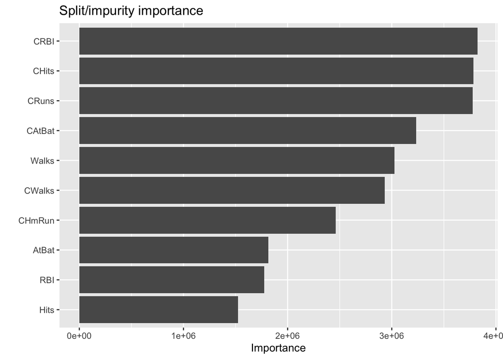

```r
library(tidymodels)
library(vip)
library(ISLR2)

Hitters2 <- Hitters %>% drop_na(Salary)

set.seed(1)
hitters_split <- initial_split(Hitters2, prop = 0.7)
hitters_train <- training(hitters_split)
hitters_test  <- testing(hitters_split)

# Two RF fits: one tracks impurity importance, one tracks permutation importance
rf_impurity_spec <-
  rand_forest(trees = 1000) %>%
  set_engine("ranger", importance = "impurity") %>%
  set_mode("regression")

rf_perm_spec <-
  rand_forest(trees = 1000) %>%
  set_engine("ranger", importance = "permutation") %>%
  set_mode("regression")

rf_impurity_fit <- workflow() %>% add_model(rf_impurity_spec) %>%
  add_formula(Salary ~ .) %>% fit(data = hitters_train)
rf_perm_fit <- workflow() %>% add_model(rf_perm_spec) %>%
  add_formula(Salary ~ .) %>% fit(data = hitters_train)

vip(extract_fit_engine(rf_impurity_fit), num_features = 10) +
  ggtitle("Split/impurity importance")
```

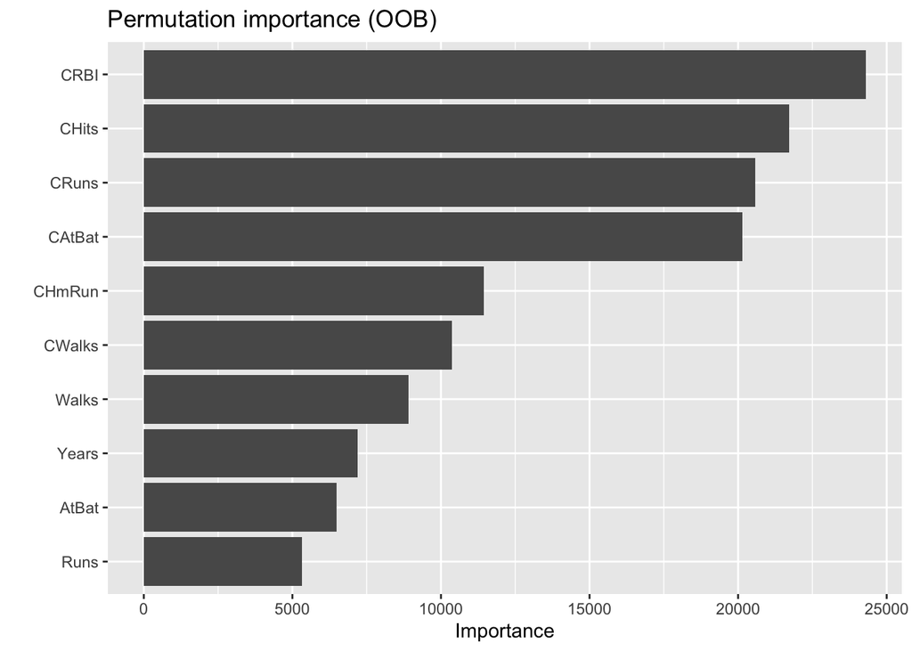

```r
vip(extract_fit_engine(rf_perm_fit), num_features = 10) +
  ggtitle("Permutation importance (OOB)")
```

**Python (sklearn)**

```python
import pandas as pd
import numpy as np
from sklearn.model_selection import train_test_split
from sklearn.compose import ColumnTransformer
from sklearn.pipeline import Pipeline
from sklearn.preprocessing import OneHotEncoder
from sklearn.impute import SimpleImputer
from sklearn.ensemble import RandomForestRegressor
from sklearn.inspection import permutation_importance

Hitters = pd.read_csv("../data/Hitters.csv")
Hitters2 = Hitters.dropna(subset=["Salary"]).copy()

y = Hitters2["Salary"].values
X = Hitters2.drop(columns=["Salary"])

cat_cols = X.select_dtypes(include=["object", "category"]).columns.tolist()
num_cols = [c for c in X.columns if c not in cat_cols]

try:
    ohe = OneHotEncoder(handle_unknown="ignore", sparse_output=False)
except TypeError:
    ohe = OneHotEncoder(handle_unknown="ignore", sparse=False)

preprocess = ColumnTransformer(
    transformers=[
        ("num", Pipeline([("impute", SimpleImputer(strategy="median"))]), num_cols),
        ("cat", Pipeline([
            ("impute", SimpleImputer(strategy="most_frequent")),
            ("onehot", ohe)
        ]), cat_cols),
    ],
    remainder="drop",
    verbose_feature_names_out=False
)

rf = RandomForestRegressor(n_estimators=1000, random_state=1, n_jobs=-1)
pipe = Pipeline(steps=[("prep", preprocess), ("model", rf)])

X_train, X_test, y_train, y_test = train_test_split(
    X, y, test_size=0.3, random_state=1
)
pipe.fit(X_train, y_train)
```

```
Pipeline(steps=[('prep',
                 ColumnTransformer(transformers=[('num',
                                                  Pipeline(steps=[('impute',
                                                                   SimpleImputer(strategy='median'))]),
                                                  ['AtBat', 'Hits', 'HmRun',
                                                   'Runs', 'RBI', 'Walks',
                                                   'Years', 'CAtBat', 'CHits',
                                                   'CHmRun', 'CRuns', 'CRBI',
                                                   'CWalks', 'PutOuts',
                                                   'Assists', 'Errors']),
                                                 ('cat',
                                                  Pipeline(steps=[('impute',
                                                                   SimpleImputer(strategy='most_frequent')),
                                                                  ('onehot',
                                                                   OneHotEncoder(handle_unknown='ignore',
                                                                                 sparse_output=False))]),
                                                  ['League', 'Division',
                                                   'NewLeague'])],
                                   verbose_feature_names_out=False)),
                ('model',
                 RandomForestRegressor(n_estimators=1000, n_jobs=-1,
                                       random_state=1))])
```

```python
# Permutation importance on held-out data
perm = permutation_importance(pipe, X_test, y_test, n_repeats=10,
                               random_state=1, n_jobs=-1)

feat_names = pipe.named_steps["prep"].get_feature_names_out()
top_idx = np.argsort(perm.importances_mean)[::-1][:10]
list(zip(feat_names[top_idx], np.round(perm.importances_mean[top_idx], 2)))
```

```
[('CRBI', np.float64(0.11)), ('CHits', np.float64(0.1)), ('RBI', np.float64(0.04)), ('CAtBat', np.float64(0.03)), ('CHmRun', np.float64(0.03)), ('Walks', np.float64(0.03)), ('CRuns', np.float64(0.02)), ('AtBat', np.float64(0.01)), ('Assists', np.float64(0.0)), ('CWalks', np.float64(0.0))]
```

# 3 SHAP: local explanations that add up

## 3.1 The idea

Permutation importance gives one number per feature (global). **SHAP** gives one number per feature **per observation** (local). For a single prediction:

$$\hat f(x) = \underbrace{\phi_0}_{\text{baseline}} + \phi_1 + \phi_2 + \cdots + \phi_p.$$

Each $\phi_j$ says: “Feature $j$ pushed this prediction up (or down) by this much.”

SHAP values come from **Shapley values** in game theory — a principled way to fairly divide credit among players in a cooperative game.

**Group project analogy.** Three students (Alice, Bob, Carla) earn a group grade. Different subsets would have earned different grades:

| Coalition | Grade |
| --- | --- |
| nobody | 50 |
| {Alice} | 70 |
| {Bob} | 60 |
| {Alice, Bob} | 85 |
| {Alice, Bob, Carla} | 92 |
| … | … |

To fairly credit Alice: look at every possible ordering the students could have joined; record Alice’s marginal contribution (grade jump when she joins); average across all orderings. That average is her Shapley value.

In ML: players = features, grade = model prediction. For tree ensembles, an algorithm called **TreeSHAP** computes this efficiently without enumerating all $2^p$ subsets.

## 3.2 Key SHAP plots

- **Beeswarm**: each dot = one observation; $x$-axis = SHAP value; color = feature value. Shows which features matter *and* the direction of their effect.
- **Waterfall**: one observation explained step-by-step from baseline to final prediction.

## 3.3 Worked example (boosted trees → SHAP)

**R (xgboost + shapviz)**

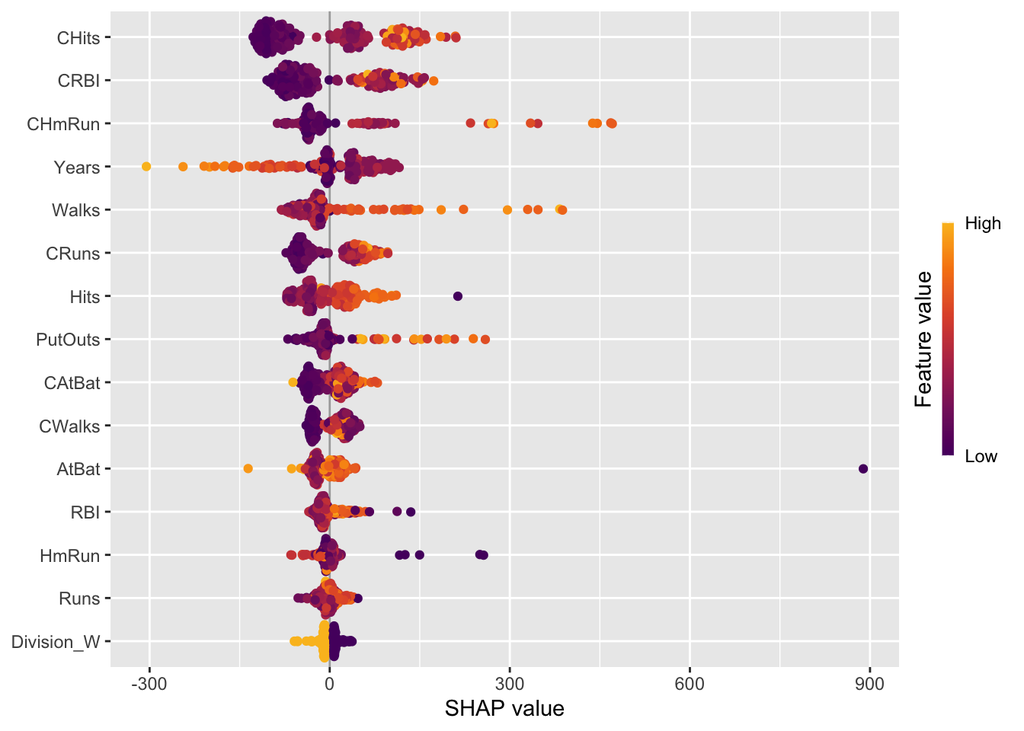

```r
library(tidymodels)
library(shapviz)

set.seed(1)

hitters_xgb_rec <-
  recipe(Salary ~ ., data = hitters_train) %>%
  step_dummy(all_nominal_predictors()) %>%
  step_zv(all_predictors())

hitters_xgb_prep <- prep(hitters_xgb_rec)
p <- juice(hitters_xgb_prep) %>% select(-Salary) %>% ncol()

xgb_spec <-
  boost_tree(trees = 500, tree_depth = 3, learn_rate = 0.05,
             sample_size = 0.8, mtry = max(1, floor(0.8 * p))) %>%
  set_engine("xgboost") %>%
  set_mode("regression")

xgb_fit <- workflow() %>% add_recipe(hitters_xgb_rec) %>%
  add_model(xgb_spec) %>% fit(data = hitters_train)

xgb_engine <- extract_fit_engine(xgb_fit)
X_train_mat <- bake(hitters_xgb_prep, new_data = hitters_train) %>%
  select(-Salary) %>% as.matrix()

sv <- shapviz(xgb_engine, X_pred = X_train_mat)

# Global: which features matter most?
sv_importance(sv, kind = "beeswarm")
```

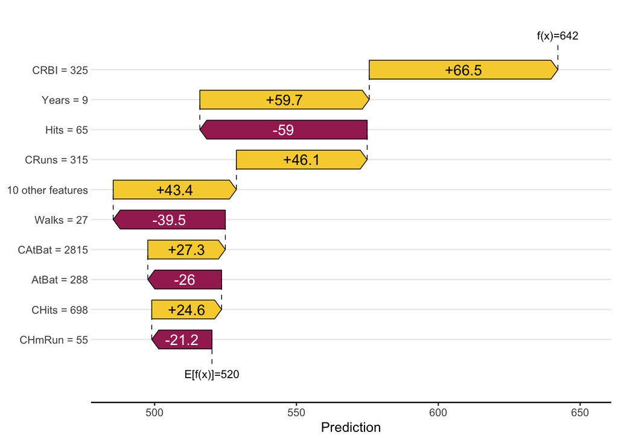

```r
# Local: explain one player's predicted salary
sv_waterfall(sv, row_id = 1)
```

**Python (sklearn + shap)**

```python
try:
    import shap
except ImportError:
    import sys, subprocess
    subprocess.check_call([sys.executable, "-m", "pip", "install", "shap"])
    import shap

from sklearn.ensemble import GradientBoostingRegressor

gbr = GradientBoostingRegressor(random_state=1)
pipe_gbr = Pipeline(steps=[("preprocess", preprocess), ("model", gbr)])
pipe_gbr.fit(X_train, y_train)
```

```
Pipeline(steps=[('preprocess',
                 ColumnTransformer(transformers=[('num',
                                                  Pipeline(steps=[('impute',
                                                                   SimpleImputer(strategy='median'))]),
                                                  ['AtBat', 'Hits', 'HmRun',
                                                   'Runs', 'RBI', 'Walks',
                                                   'Years', 'CAtBat', 'CHits',
                                                   'CHmRun', 'CRuns', 'CRBI',
                                                   'CWalks', 'PutOuts',
                                                   'Assists', 'Errors']),
                                                 ('cat',
                                                  Pipeline(steps=[('impute',
                                                                   SimpleImputer(strategy='most_frequent')),
                                                                  ('onehot',
                                                                   OneHotEncoder(handle_unknown='ignore',
                                                                                 sparse_output=False))]),
                                                  ['League', 'Division',
                                                   'NewLeague'])],
                                   verbose_feature_names_out=False)),
                ('model', GradientBoostingRegressor(random_state=1))])
```

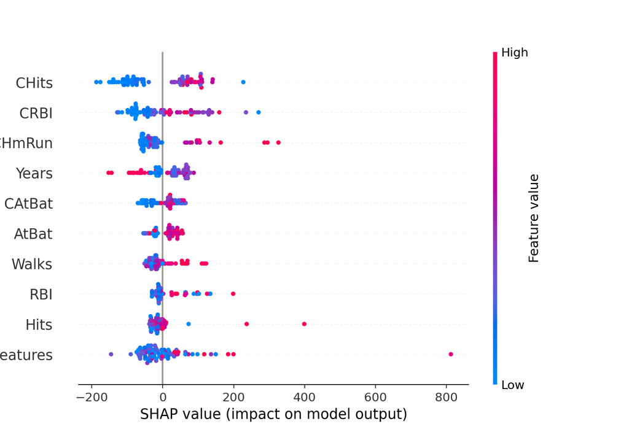

```python
# Extract transformed features for SHAP
X_train_trans = pipe_gbr.named_steps["preprocess"].transform(X_train)
X_test_trans  = pipe_gbr.named_steps["preprocess"].transform(X_test)
feat_names = pipe_gbr.named_steps["preprocess"].get_feature_names_out()

X_train_shap = pd.DataFrame(X_train_trans, columns=feat_names)
X_test_shap  = pd.DataFrame(X_test_trans,  columns=feat_names)

model = pipe_gbr.named_steps["model"]

# TreeSHAP: background = training data, explain = test observations
explainer = shap.Explainer(model, X_train_shap)
shap_values = explainer(X_test_shap)

# Global: beeswarm
shap.plots.beeswarm(shap_values, max_display=10)
```

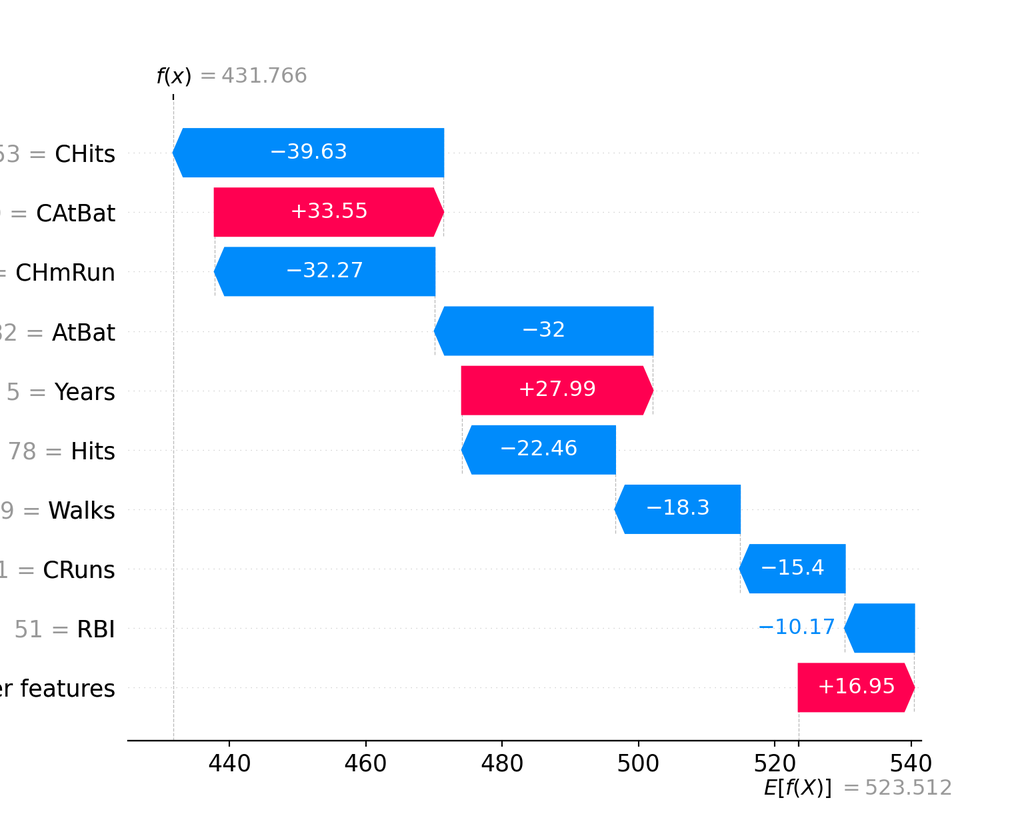

```python
# Local: waterfall for one test observation
shap.plots.waterfall(shap_values[0])
```

# 4 Quick reference

|  | Split / Gain | Permutation | SHAP |
| --- | --- | --- | --- |
| **What it gives** | Importance ranking | Importance ranking | Local + global explanations |
| **Global or local?** | Global | Global | Both |
| **Model-agnostic?** | Trees only | Any model | Practical for trees; possible for others |
| **Correlation caveat** | Shares credit | Underestimates (substitution) | Shares credit |
| **Speed** | Free | Moderate | Fast for trees (TreeSHAP) |

### 4.0.1 Recommended workflow

1. Fit your tree ensemble (RF or boosting).
2. **Split importance** for a quick first look; **permutation importance** for a more reliable ranking.
3. **SHAP beeswarm** to see direction of effects; **waterfall** to explain individual predictions.